[GitHub](https://github.com/JuliaGeometry/DelaunayTriangulation.jl)[](https://github.com/JuliaGeometry/DelaunayTriangulation.jl/tree/main/docs/src/literate_tutorials/operations_vertex_insertion_deletion.jl)

# Triangulation Operations

## Vertex Insertion and Deletion

This tutorial demonstrates how to insert and delete vertices from a triangulation while maintaining the Delaunay property of the triangulation. First, load the packages we need:

```julia
using DelaunayTriangulation
using CairoMakie
using StableRNGs
```

Let us now define our initial triangulation.

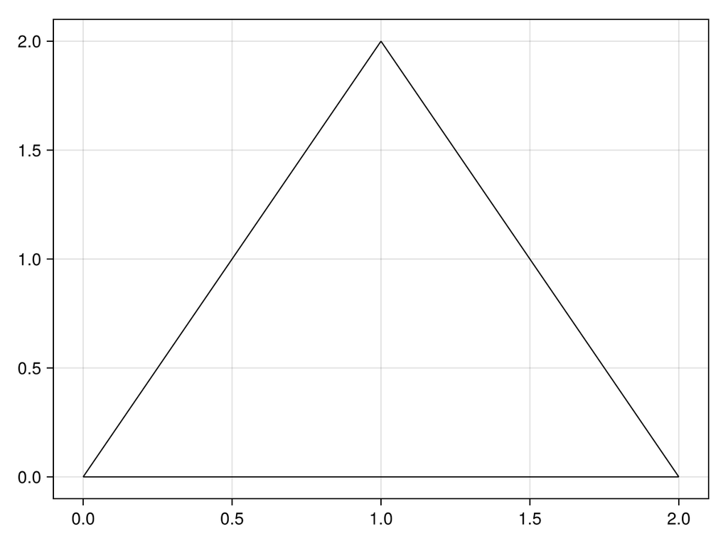

```julia
points = [(0.0, 0.0), (2.0, 0.0), (1.0, 2.0)]
tri = triangulate(points)
fig, ax, sc = triplot(tri)
fig
```

Note that we use a structure for `points` that is mutable so that points can be pushed into it.

We now want to insert a vertex into the triangulation. To do this, we use `add_point!` and provide the coordinates of the new point. There is a method which uses the index of the vertex rather than the coordinates, but we don't use that here as the points to be added are not already in `points`. Here, we add a point at `(1.0, 0.5)`.

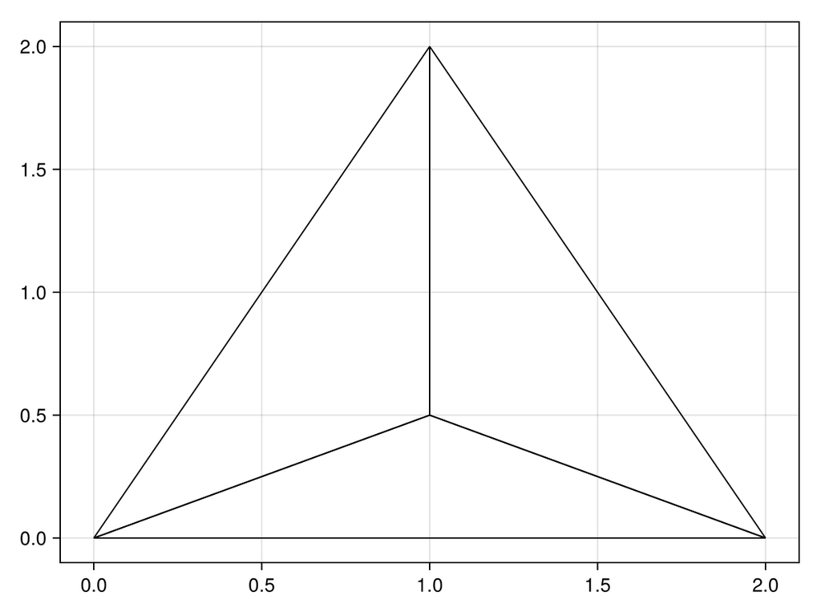

```julia
add_point!(tri, 1.0, 0.5)
fig, ax, sc = triplot(tri)
fig
```

This is still a valid Delaunay triangulation, unsurprisingly due to the small number of points. We can also add points that are outside of the triangulation:

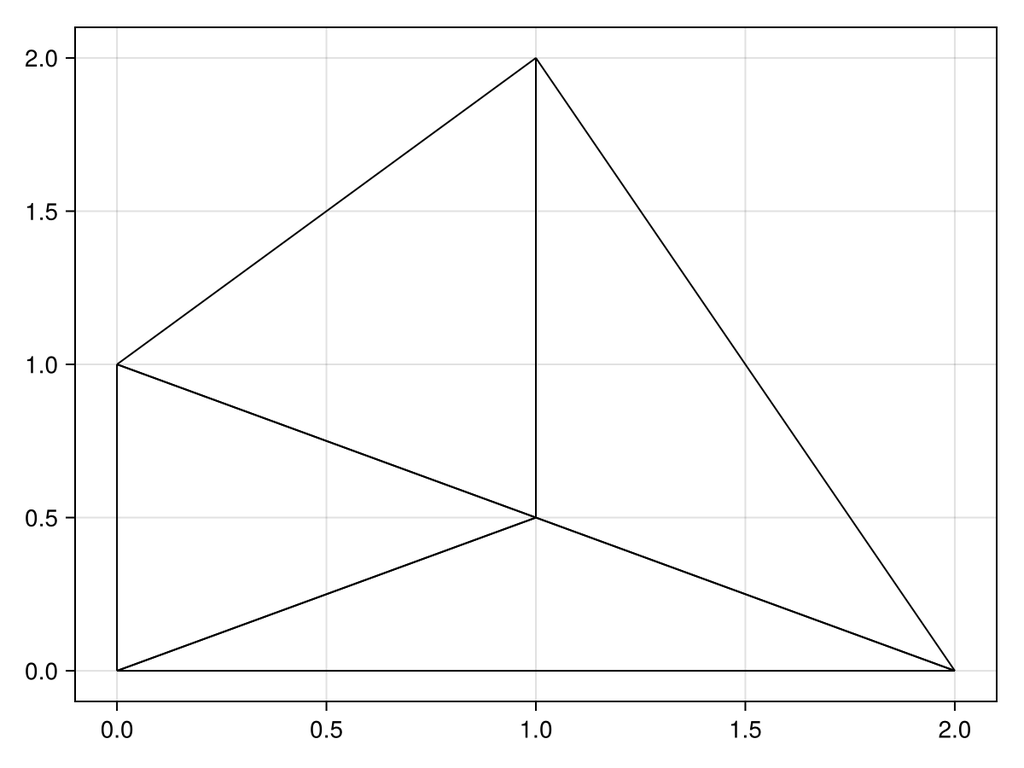

```julia
add_point!(tri, 0.0, 1.0)
fig, ax, sc = triplot(tri)
fig
```

One important thing to note here is that, if not for the ghost triangles inside `tri`, adding a point outside of the triangulation would not work. Here is an example of this failing.

```julia
delete_ghost_triangles!(tri)
add_point!(tri, 2.0, 1.5)
```

```
BoundsError([(0.0, 0.0), (2.0, 0.0), (1.0, 2.0), (1.0, 0.5), (0.0, 1.0)], (0,))
```

This is a `BoundsError`, because the triangulation has had to walk into the boundary but failed to find any ghost triangles. Anytime you need to perform some operation including a point outside of the boundary, you need to be sure that you have ghost triangles, which you can query using `DelaunayTriangulation.has_ghost_triangles`.

```julia
DelaunayTriangulation.has_ghost_triangles(tri)
```

```
false
```

```julia
add_ghost_triangles!(tri)
```

```
Delaunay Triangulation.
   Number of vertices: 5
   Number of triangles: 4
   Number of edges: 8
   Has boundary nodes: false
   Has ghost triangles: true
   Curve-bounded: false
   Weighted: false
   Constrained: false
```

```julia
DelaunayTriangulation.has_ghost_triangles(tri)
```

```
true
```

Another issue is that the convex hull is not updated as we add (or delete) points for performance reasons:

```julia
get_convex_hull_vertices(tri)
```

```
4-element Vector{Int64}:
 3
 1
 2
 3
```

If we do want to fix the convex hull, we can use `convex_hull!(tri)`.

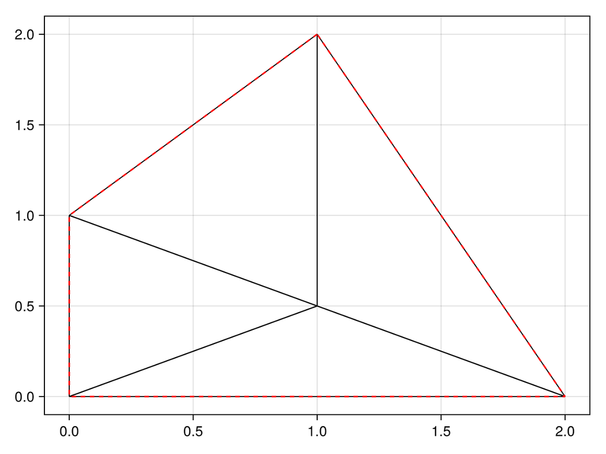

```julia
convex_hull!(tri)
fig, ax, sc = triplot(tri, show_convex_hull=true)
fig
```

We now have the same triangulation that we would have had if we had done `triangulate` on this set of points originally. To now push this further, let's add in a bunch of random points.

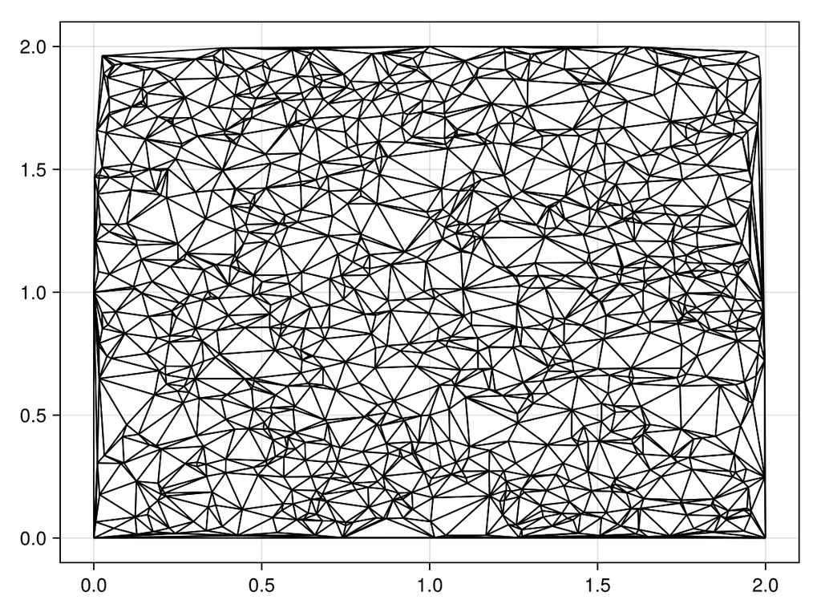

```julia
rng = StableRNG(123)
for _ in 1:1000
    new_point = 2rand(rng, 2)
    add_point!(tri, new_point)
end
fig, ax, sc = triplot(tri)
fig
```

Let us now demonstrate how to delete points. To do this, we use `delete_point!`. This function takes vertices rather than coordinates, identifying the corresponding point in `points` by its index. Let us demonstrate this operation by deleting all points within a distance of `1/2` around `(1.0, 1.0)`.

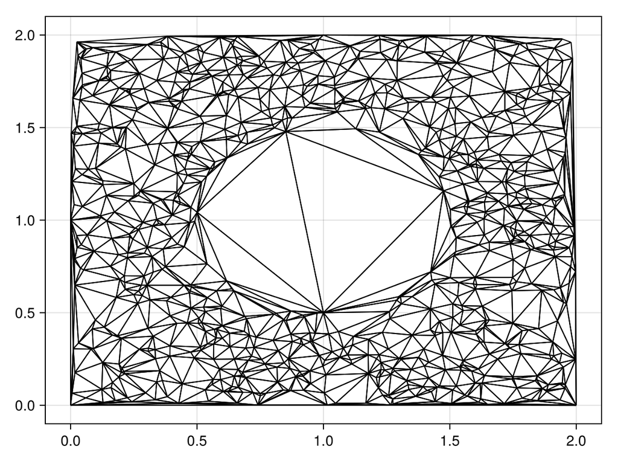

```julia
vertices_to_delete = Iterators.filter(each_solid_vertex(tri)) do i
    p = get_point(tri, i)
    r2 = (getx(p) - 1.0)^2 + (gety(p) - 1.0)^2
    return r2 < 1 / 2^2
end
for i in vertices_to_delete
    delete_point!(tri, i)
end
fig, ax, sc = triplot(tri)
fig
```

Note that in this situation, `points` still contains those points that we have now deleted. This is the reason to be careful about using, say, `DelaunayTriangulation.each_point` rather than `each_solid_vertex`. This triangulation is also still Delaunay.

## Just the code

An uncommented version of this example is given below. You can view the source code for this file [here](https://github.com/JuliaGeometry/DelaunayTriangulation.jl/tree/main/docs/src/literate_tutorials/operations_vertex_insertion_deletion.jl).

```julia
using DelaunayTriangulation
using CairoMakie
using StableRNGs

points = [(0.0, 0.0), (2.0, 0.0), (1.0, 2.0)]
tri = triangulate(points)
fig, ax, sc = triplot(tri)
fig

add_point!(tri, 1.0, 0.5)
fig, ax, sc = triplot(tri)
fig

add_point!(tri, 0.0, 1.0)
fig, ax, sc = triplot(tri)
fig

delete_ghost_triangles!(tri)
add_point!(tri, 2.0, 1.5)

DelaunayTriangulation.has_ghost_triangles(tri)

add_ghost_triangles!(tri)

DelaunayTriangulation.has_ghost_triangles(tri)

get_convex_hull_vertices(tri)

convex_hull!(tri)
fig, ax, sc = triplot(tri, show_convex_hull=true)
fig

rng = StableRNG(123)
for _ in 1:1000
    new_point = 2rand(rng, 2)
    add_point!(tri, new_point)
end
fig, ax, sc = triplot(tri)
fig

vertices_to_delete = Iterators.filter(each_solid_vertex(tri)) do i
    p = get_point(tri, i)
    r2 = (getx(p) - 1.0)^2 + (gety(p) - 1.0)^2
    return r2 < 1 / 2^2
end
for i in vertices_to_delete
    delete_point!(tri, i)
end
fig, ax, sc = triplot(tri)
fig
```

*This page was generated using Literate.jl.*